# Tutorium 9

Gruppen 5 und 7  
Samuel Teuber  
propa@teuber.dev  
https://teuber.dev/propa

# Übungsblätter

- Fragen?
- Probleme?
- Zu schwierig?

# Aufgabe 1 - Tester

```
even(0).
even(X) :- X>0, X1 is X-1, odd(X1).
odd(1).
odd(X) :- X>1, X1 is X-1, even(X1).
```

Was passiert, wenn man hier `?even(X)` aufruft?

# Aufgabe 1 - Generator

```
even(0).
even(X) :- odd(Y), X is Y+1, X>0.
odd(1).
odd(X) :- even(Y), X is Y+1, X>1.
```

Was passiert, wenn man hier `?odd(7)` aufruft?  
Wie unterscheidet sich das zu `?odd(8)`?

# Aufgabe 1 - Teil 2

Was passiert, wenn bei den Generatoren die Teilziele X>0 und X>1 weggelassen werden?

```
even(0).
even(X) :- odd(Y), X is Y+1, X>0.
odd(1).
odd(X) :- even(Y), X is Y+1, X>1.
```

- `X>1`: Reerfüllung von `odd(1)` über `even(0)`, damit auch `even` reerfüllbar
- `X>0`: Überflüssig

# Aufgabe 1 - Ausführungsbaum

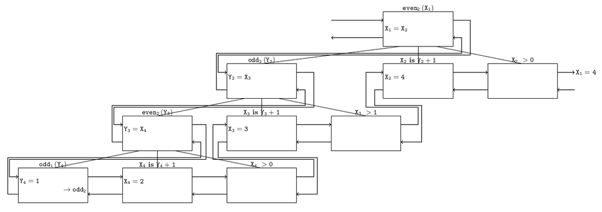

# Aufgabe 2

```
del1([],_,[]).
del1([X|T1],X,L2) :- !, del1(T1,X,L2).
del1([Y|T1],X,[Y|T2]) :- del1(T1,X,T2).

del2([],_,[]).
del2([X|T1],X,L2) :- del2(T1,X,L2).
del2([Y|T1],X,[Y|T2]) :- del2(T1,X,T2), not(X=Y).

del3([X|L],X,L).
del3([Y|T1],X,[Y|T2]) :- del3(T1,X,T2).
```

**Anfrage:** `deli([1,2,1],X,L).`

- `del1` bricht nach erster erfüllbaren Belegung ab: `X=1,L=[2]`
- `del2` ist für `X` reerfüllbar: `X=1,L=[2]; X=2,L=[1,1]`
- `del3` ist reerfüllbar und löscht nur ein Vorkommen: `X=1,L=[2,1]; X=2,L=[1,1]; X=1,L[1,2]`

# Aufgabe 2 - Teil 2

```
del1([],_,[]).
del1([X|T1],X,L2) :- !, del1(T1,X,L2).
del1([Y|T1],X,[Y|T2]) :- del1(T1,X,T2).

del2([],_,[]).
del2([X|T1],X,L2) :- del2(T1,X,L2).
del2([Y|T1],X,[Y|T2]) :- del2(T1,X,T2), not(X=Y).

del3([X|L],X,L).
del3([Y|T1],X,[Y|T2]) :- del3(T1,X,T2).
```

- `deli(L, 2, [1, 3]).`: Nur 3
- `deli([1, 2, 3], X, [1, 3]).`: Nur 2 und 3 (wegen Cut)
- `deli([1, 2, 3, 2], X, [1, 3]).`: Nur 2
- `deli([1, 2, 3, 2], X, [1, 2, 3]).`: Nur 3
- `deli([1|L], 1, X).`: Alle

# Aufgabe 2 - Freie Variablen

```
?fv(app(abs(x, abs(y, app(app(x,z), 17))), u), F).
F = [z,u]
```

Wir brauchen Regeln für jede mögliche Komponente:

- Zahl
- Atom
- Abstraktion
- Applikation

```
fv(X,[]) :- integer(X).
fv(X,[X]):- atom(X).
fv(abs(X,Y),R) :- fv(Y,L), del2(L,X,R).
fv(app(X,Y),R) :- fv(X,L1), fv(Y,L2), append(L1, L2, R).
```

# Unifikation (1)

## Substitution

$$ \sigma = \{X_2⇨X_1\}\\ \sigma\left(\ f\left(X_1, Y\right)=X_2\ \right) = f(X_1, Y)=X_1 $$

$$ \theta = \{X_1 ⇨ Y, Y ⇨ Z\}\\ \theta\left(\ \sigma\left(\ f\left(X_1, Y\right)=X_2\ \right)\ \right) = f(Y, Z)=Y $$

Eine Substitution wird **überall**, **einmal**, **gleichzeitig** durchgeführt!

$$ \theta \circ \sigma = \{ X_1 ⇨ Y, X_2 ⇨ Y, Y ⇨ Z \} $$

## Gleichungssysteme

$$ X_1 = X_2\\ X_2 = X_3\\ X_3 = X_4 $$

Welche Substitution $\sigma$, damit das Gleichungssystem gültig ist? **(1 min)**

# Unifikation (2)

## Komplexere Gleichungssysteme

$$ f(X_1,X_2,X_3) = Z\\ f(A,B,C) = X\\ X=Z $$

- Mit $X=Z$ $$ f(A,B,C)=f(X_1,X_2,X_3) $$
- Kann nur garantiert werden, wenn: $$ A=X_1\\ B=X_2\\ C=X_3 $$
- **Unifikator**: $$ \{X_1⇨A, X_2⇨B, X_3⇨C\}\circ \{X⇨f\left(A,B,C\right), Z⇨f\left(X_1,X_2,X_3\right)\} $$
- Zusammengefasst ergibt das: $$ \{X_1⇨A, X_2⇨B, X_3⇨C, X⇨f\left(A,B,C\right), Z⇨f\left(A,B,C\right)\} $$

# Unifikation (3)

## Most general unifier (mgu)

- Vorher: $$ \sigma = \{X_1⇨A, X_2⇨B, X_3⇨C, X⇨f\left(A,B,C\right), Z⇨f\left(A,B,C\right)\} $$
- Auch möglich: $$ \gamma = \{X_1⇨A, X_2⇨\color{red}{A}, X_3⇨\color{red}{A, B⇨A, C⇨A}, X⇨f\left(A,\color{red}{A,A}\right), Z⇨f\left(A,\color{red}{A,A}\right)\} $$

**ABER:** $$ \gamma = \{B⇨A, C⇨A\} \circ \sigma $$

$\sigma$ ist allgemeiner als $\gamma$

Wir nennen $\sigma$ den **most general unifier (mgu)**, wenn für alle Unifikatoren $\gamma$ gilt es gibt einen zugehörigen Unifikator $\theta$, sodass: $$ \gamma = \theta \circ \sigma $$

**Wie finden wir den mgu?**

# Algorithmische Lösung: Robinson

```
function unify(C) {
    if (C.empty()) {
        return []
    } else {
        (T1 = T2) := C.pop()
        if (T1 == T2)
        { return unify(C) }

        else if (T1.isVar() && !T2.isFree(T1))
        { return compose( unify([T1->T2]C), [T1->T2]) }

        else if (T2.isVar() && !T1.isFree(T2))
        { return compose( unify([T2->T1]C), [T2->T1]) }

        else {
            f(X1,...,XN) := T1
            g(Y1,...,YN) := T2
            if (g != f) { fail(); }
            else { return unify( C+[X1=Y1,...,XN=YN]) }
        }
    }
}
```

**Übung zu manueller Ausführung von Robinson**

# Geldwechselmaschine

Aufgabe und Lösung: https://pp.info.uni-karlsruhe.de/lehre/WS201819/paradigmen/uebung/blaetter/blatt8-zusatz-solutions.pdf

```python
remove([(C,N)|Coins],C,[(C,N1)|Coins]) :- N > 0, N1 is N - 1.
remove([(C,N)|Coins],C1,[(C,N)|CoinsNew]) :- remove(Coins,C1,CoinsNew).

put([],X,[(X,1)]).
put([(W,A)|T],W,[(W,A1)|T]) :- !, A1 is A+1.
put([(W,A)|T],X,[(W,A)|T1]) :- put(T,X,T1).

change(0,_,[]).
change(X, Coins, ChangeNew) :-
    remove(Coins, C, CoinsNew),
    X>=C, Xnew is X-C,
    change(Xnew, CoinsNew, Change),
    put(Change, C, ChangeNew).

QUERYSTART
change(100, [(50,2),(20,2),(10,1),(5,3)], R)
QUERYEND
```

```
Warning: /tmp/tmpj2nwzus2/code.pl:24:
	Singleton variables: [R]

-----------------------------------------
 Call of: 	 change(100,[(50,2),(20,2),(10,1),(5,3)],_3490)
 TRUE with:	 change(100,[(50,2),(20,2),(10,1),(5,3)],[(50,2)])
 TRUE with:	 change(100,[(50,2),(20,2),(10,1),(5,3)],[(10,1),(20,2),(50,1)])
 TRUE with:	 change(100,[(50,2),(20,2),(10,1),(5,3)],[(5,2),(20,2),(50,1)])
 TRUE with:	 change(100,[(50,2),(20,2),(10,1),(5,3)],[(20,2),(10,1),(50,1)])
 TRUE with:	 change(100,[(50,2),(20,2),(10,1),(5,3)],[(5,2),(20,2),(50,1)])
 TRUE with:	 change(100,[(50,2),(20,2),(10,1),(5,3)],[(20,2),(5,2),(50,1)])
 TRUE with:	 change(100,[(50,2),(20,2),(10,1),(5,3)],[(20,2),(10,1),(50,1)])
 TRUE with:	 change(100,[(50,2),(20,2),(10,1),(5,3)],[(5,2),(20,2),(50,1)])
 TRUE with:	 change(100,[(50,2),(20,2),(10,1),(5,3)],[(20,2),(5,2),(50,1)])
 TRUE with:	 change(100,[(50,2),(20,2),(10,1),(5,3)],[(20,2),(5,2),(50,1)])
 TRUE with:	 change(100,[(50,2),(20,2),(10,1),(5,3)],[(10,1),(20,2),(50,1)])
 TRUE with:	 change(100,[(50,2),(20,2),(10,1),(5,3)],[(5,2),(20,2),(50,1)])
 TRUE with:	 change(100,[(50,2),(20,2),(10,1),(5,3)],[(20,2),(10,1),(50,1)])
 TRUE with:	 change(100,[(50,2),(20,2),(10,1),(5,3)],[(5,2),(20,2),(50,1)])
 TRUE with:	 change(100,[(50,2),(20,2),(10,1),(5,3)],[(20,2),(5,2),(50,1)])
 TRUE with:	 change(100,[(50,2),(20,2),(10,1),(5,3)],[(10,1),(50,1),(20,2)])
 TRUE with:	 change(100,[(50,2),(20,2),(10,1),(5,3)],[(5,2),(50,1),(20,2)])
 TRUE with:	 change(100,[(50,2),(20,2),(10,1),(5,3)],[(50,1),(10,1),(20,2)])
 TRUE with:	 change(100,[(50,2),(20,2),(10,1),(5,3)],[(5,2),(50,1),(20,2)])
 TRUE with:	 change(100,[(50,2),(20,2),(10,1),(5,3)],[(50,1),(5,2),(20,2)])
 TRUE with:	 change(100,[(50,2),(20,2),(10,1),(5,3)],[(20,2),(50,1),(10,1)])
 TRUE with:	 change(100,[(50,2),(20,2),(10,1),(5,3)],[(50,1),(20,2),(10,1)])
 TRUE with:	 change(100,[(50,2),(20,2),(10,1),(5,3)],[(5,2),(20,2),(50,1)])
 TRUE with:	 change(100,[(50,2),(20,2),(10,1),(5,3)],[(20,2),(5,2),(50,1)])
 TRUE with:	 change(100,[(50,2),(20,2),(10,1),(5,3)],[(5,2),(50,1),(20,2)])
 TRUE with:	 change(100,[(50,2),(20,2),(10,1),(5,3)],[(50,1),(5,2),(20,2)])
 TRUE with:	 change(100,[(50,2),(20,2),(10,1),(5,3)],[(20,2),(50,1),(5,2)])
 TRUE with:	 change(100,[(50,2),(20,2),(10,1),(5,3)],[(50,1),(20,2),(5,2)])
 TRUE with:	 change(100,[(50,2),(20,2),(10,1),(5,3)],[(20,2),(50,1),(10,1)])
 TRUE with:	 change(100,[(50,2),(20,2),(10,1),(5,3)],[(20,2),(50,1),(10,1)])
 TRUE with:	 change(100,[(50,2),(20,2),(10,1),(5,3)],[(50,1),(20,2),(10,1)])
 TRUE with:	 change(100,[(50,2),(20,2),(10,1),(5,3)],[(5,2),(20,2),(50,1)])
 TRUE with:	 change(100,[(50,2),(20,2),(10,1),(5,3)],[(20,2),(5,2),(50,1)])
 TRUE with:	 change(100,[(50,2),(20,2),(10,1),(5,3)],[(20,2),(5,2),(50,1)])
 TRUE with:	 change(100,[(50,2),(20,2),(10,1),(5,3)],[(5,2),(20,2),(50,1)])
 TRUE with:	 change(100,[(50,2),(20,2),(10,1),(5,3)],[(20,2),(5,2),(50,1)])
 TRUE with:	 change(100,[(50,2),(20,2),(10,1),(5,3)],[(5,2),(50,1),(20,2)])
 TRUE with:	 change(100,[(50,2),(20,2),(10,1),(5,3)],[(50,1),(5,2),(20,2)])
 TRUE with:	 change(100,[(50,2),(20,2),(10,1),(5,3)],[(20,2),(50,1),(5,2)])
 TRUE with:	 change(100,[(50,2),(20,2),(10,1),(5,3)],[(50,1),(20,2),(5,2)])
 TRUE with:	 change(100,[(50,2),(20,2),(10,1),(5,3)],[(20,2),(50,1),(5,2)])
 TRUE with:	 change(100,[(50,2),(20,2),(10,1),(5,3)],[(20,2),(50,1),(5,2)])
 TRUE with:	 change(100,[(50,2),(20,2),(10,1),(5,3)],[(50,1),(20,2),(5,2)])
```